# Homework Week 4

### Question 9.1

Using the same crime data set uscrime.txt as in Question 8.2, apply Principal Component Analysis and then create a regression model using the first few principal components. Specify your new model in terms of the original variables (not the principal components), and compare its quality to that of your solution to Question 8.2. You can use the R function prcomp for PCA. (Note that to first scale the data, you can include scale. = TRUE to scale as part of the PCA function. Don’t forget that, to make a prediction for the new city, you’ll need to unscale the coefficients (i.e., do the scaling calculation in reverse)!)

#### Answer

```r
#install.packages("factoextra")
#install.packages("rpart")
#install.packages("rpart.plot")
#install.packages("tree")
install.packages("randomForest")
library(dplyr)
library(factoextra)
library(GGally)
library(rpart)
library(rpart.plot)
library(tree)
library(randomForest)
```

```r
#### Load data and store as variable
CrimeData <- read.table(url("http://www.statsci.org/data/general/uscrime.txt"), header = TRUE)
head(CrimeData)
```

|  | M | So | Ed | Po1 | Po2 | LF | M.F | Pop | NW | U1 | U2 | Wealth | Ineq | Prob | Time | Crime |
| --- | --- | --- | --- | --- | --- | --- | --- | --- | --- | --- | --- | --- | --- | --- | --- | --- |
| 1 | 15.1 | 1 | 9.1 | 5.8 | 5.6 | 0.510 | 95.0 | 33 | 30.1 | 0.108 | 4.1 | 3940 | 26.1 | 0.084602 | 26.2011 | 791 |
| 2 | 14.3 | 0 | 11.3 | 10.3 | 9.5 | 0.583 | 101.2 | 13 | 10.2 | 0.096 | 3.6 | 5570 | 19.4 | 0.029599 | 25.2999 | 1635 |
| 3 | 14.2 | 1 | 8.9 | 4.5 | 4.4 | 0.533 | 96.9 | 18 | 21.9 | 0.094 | 3.3 | 3180 | 25.0 | 0.083401 | 24.3006 | 578 |
| 4 | 13.6 | 0 | 12.1 | 14.9 | 14.1 | 0.577 | 99.4 | 157 | 8.0 | 0.102 | 3.9 | 6730 | 16.7 | 0.015801 | 29.9012 | 1969 |
| 5 | 14.1 | 0 | 12.1 | 10.9 | 10.1 | 0.591 | 98.5 | 18 | 3.0 | 0.091 | 2.0 | 5780 | 17.4 | 0.041399 | 21.2998 | 1234 |
| 6 | 12.1 | 0 | 11.0 | 11.8 | 11.5 | 0.547 | 96.4 | 25 | 4.4 | 0.084 | 2.9 | 6890 | 12.6 | 0.034201 | 20.9995 | 682 |

```r
NA
```

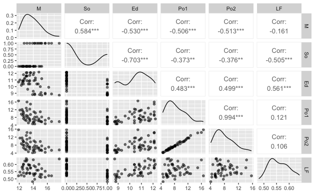

```r
#### Visualizing of distribution of potential clusters in the iris dataset
pairplot <- ggpairs(CrimeData,
        columns = 1:6,
        aes(alpha = 0.5)) #transparency

pairplot
```

So it seems we have some factors that are highly correlated with each other. We can use principal component analysis (PCA) to to remove the correlations and rank coordinates by importance (Sokol Lesson 9.3).

Before we do a PCA we will first grab all of the predictor columns into one variable and the response column as a separate variable

```r
#### Make feature and response variables

predictors <- CrimeData %>% select(-16)

response <- CrimeData %>% select(16)
predictors
```

| M | So | Ed | Po1 | Po2 | LF | M.F | Pop | NW | U1 | U2 | Wealth | Ineq | Prob | Time |
| --- | --- | --- | --- | --- | --- | --- | --- | --- | --- | --- | --- | --- | --- | --- |
| 15.1 | 1 | 9.1 | 5.8 | 5.6 | 0.510 | 95.0 | 33 | 30.1 | 0.108 | 4.1 | 3940 | 26.1 | 0.084602 | 26.2011 |
| 14.3 | 0 | 11.3 | 10.3 | 9.5 | 0.583 | 101.2 | 13 | 10.2 | 0.096 | 3.6 | 5570 | 19.4 | 0.029599 | 25.2999 |
| 14.2 | 1 | 8.9 | 4.5 | 4.4 | 0.533 | 96.9 | 18 | 21.9 | 0.094 | 3.3 | 3180 | 25.0 | 0.083401 | 24.3006 |
| 13.6 | 0 | 12.1 | 14.9 | 14.1 | 0.577 | 99.4 | 157 | 8.0 | 0.102 | 3.9 | 6730 | 16.7 | 0.015801 | 29.9012 |
| 14.1 | 0 | 12.1 | 10.9 | 10.1 | 0.591 | 98.5 | 18 | 3.0 | 0.091 | 2.0 | 5780 | 17.4 | 0.041399 | 21.2998 |
| 12.1 | 0 | 11.0 | 11.8 | 11.5 | 0.547 | 96.4 | 25 | 4.4 | 0.084 | 2.9 | 6890 | 12.6 | 0.034201 | 20.9995 |
| 12.7 | 1 | 11.1 | 8.2 | 7.9 | 0.519 | 98.2 | 4 | 13.9 | 0.097 | 3.8 | 6200 | 16.8 | 0.042100 | 20.6993 |
| 13.1 | 1 | 10.9 | 11.5 | 10.9 | 0.542 | 96.9 | 50 | 17.9 | 0.079 | 3.5 | 4720 | 20.6 | 0.040099 | 24.5988 |
| 15.7 | 1 | 9.0 | 6.5 | 6.2 | 0.553 | 95.5 | 39 | 28.6 | 0.081 | 2.8 | 4210 | 23.9 | 0.071697 | 29.4001 |
| 14.0 | 0 | 11.8 | 7.1 | 6.8 | 0.632 | 102.9 | 7 | 1.5 | 0.100 | 2.4 | 5260 | 17.4 | 0.044498 | 19.5994 |

[output cut: 37 more lines]

```r
response
```

| Crime |
| --- |
| 791 |
| 1635 |
| 578 |
| 1969 |
| 1234 |
| 682 |
| 963 |
| 1555 |
| 856 |
| 705 |

[output cut: 37 more lines]

```r
NA
```

Now we can generate our PCA plot for our predictors dataset.

```r
set.seed(100)
predictors_PCA <- prcomp(predictors, scale = TRUE)
summary(predictors_PCA)
```

```
Importance of components:
                          PC1    PC2    PC3     PC4     PC5     PC6     PC7     PC8     PC9    PC10    PC11    PC12    PC13   PC14    PC15
Standard deviation     2.4534 1.6739 1.4160 1.07806 0.97893 0.74377 0.56729 0.55444 0.48493 0.44708 0.41915 0.35804 0.26333 0.2418 0.06793
Proportion of Variance 0.4013 0.1868 0.1337 0.07748 0.06389 0.03688 0.02145 0.02049 0.01568 0.01333 0.01171 0.00855 0.00462 0.0039 0.00031
Cumulative Proportion  0.4013 0.5880 0.7217 0.79920 0.86308 0.89996 0.92142 0.94191 0.95759 0.97091 0.98263 0.99117 0.99579 0.9997 1.00000
```

```r
predictors_PCA
```

```
Standard deviations (1, .., p=15):
 [1] 2.45335539 1.67387187 1.41596057 1.07805742 0.97892746 0.74377006 0.56729065 0.55443780 0.48492813 0.44708045 0.41914843 0.35803646 0.26332811
[14] 0.24180109 0.06792764

Rotation (n x k) = (15 x 15):
               PC1         PC2           PC3         PC4         PC5          PC6         PC7         PC8         PC9        PC10        PC11
M      -0.30371194  0.06280357  0.1724199946 -0.02035537 -0.35832737 -0.449132706 -0.15707378 -0.55367691  0.15474793 -0.01443093  0.39446657
So     -0.33088129 -0.15837219  0.0155433104  0.29247181 -0.12061130 -0.100500743  0.19649727  0.22734157 -0.65599872  0.06141452  0.23397868
Ed      0.33962148  0.21461152  0.0677396249  0.07974375 -0.02442839 -0.008571367 -0.23943629 -0.14644678 -0.44326978  0.51887452 -0.11821954
Po1     0.30863412 -0.26981761  0.0506458161  0.33325059 -0.23527680 -0.095776709  0.08011735  0.04613156  0.19425472 -0.14320978 -0.13042001
Po2     0.31099285 -0.26396300  0.0530651173  0.35192809 -0.20473383 -0.119524780  0.09518288  0.03168720  0.19512072 -0.05929780 -0.13885912
LF      0.17617757  0.31943042  0.2715301768 -0.14326529 -0.39407588  0.504234275 -0.15931612  0.25513777  0.14393498  0.03077073  0.38532827
M.F     0.11638221  0.39434428 -0.2031621598  0.01048029 -0.57877443 -0.074501901  0.15548197 -0.05507254 -0.24378252 -0.35323357 -0.28029732
Pop     0.11307836 -0.46723456  0.0770210971 -0.03210513 -0.08317034  0.547098563  0.09046187 -0.59078221 -0.20244830 -0.03970718  0.05849643
NW     -0.29358647 -0.22801119  0.0788156621  0.23925971 -0.36079387  0.051219538 -0.31154195  0.20432828  0.18984178  0.49201966 -0.20695666
U1      0.04050137  0.00807439 -0.6590290980 -0.18279096 -0.13136873  0.017385981 -0.17354115 -0.20206312  0.02069349  0.22765278 -0.17857891
U2      0.01812228 -0.27971336 -0.5785006293 -0.06889312 -0.13499487  0.048155286 -0.07526787  0.24369650  0.05576010 -0.04750100  0.47021842
Wealth  0.37970331 -0.07718862  0.0100647664  0.11781752  0.01167683 -0.154683104 -0.14859424  0.08630649 -0.23196695 -0.11219383  0.31955631
Ineq   -0.36579778 -0.02752240 -0.0002944563 -0.08066612 -0.21672823  0.272027031  0.37483032  0.07184018 -0.02494384 -0.01390576 -0.18278697
Prob   -0.25888661  0.15831708 -0.1176726436  0.49303389  0.16562829  0.283535996 -0.56159383 -0.08598908 -0.05306898 -0.42530006 -0.08978385
Time   -0.02062867 -0.38014836  0.2235664632 -0.54059002 -0.14764767 -0.148203050 -0.44199877  0.19507812 -0.23551363 -0.29264326 -0.26363121
              PC12        PC13        PC14          PC15
M       0.16580189  0.05142365  0.04901705 -0.0051398012
So     -0.05753357  0.29368483 -0.29364512 -0.0084369230
Ed      0.47786536 -0.19441949  0.03964277  0.0280052040
Po1     0.22611207  0.18592255 -0.09490151  0.6894155129
Po2     0.19088461  0.13454940 -0.08259642 -0.7200270100
LF      0.02705134  0.27742957 -0.15385625 -0.0336823193
M.F    -0.23925913 -0.31624667 -0.04125321 -0.0097922075
Pop    -0.18350385 -0.12651689 -0.05326383 -0.0001496323
NW     -0.36671707 -0.22901695  0.13227774  0.0370783671
U1     -0.09314897  0.59039450 -0.02335942 -0.0111359325
U2      0.28440496 -0.43292853 -0.03985736 -0.0073618948
Wealth -0.32172821  0.14077972  0.70031840  0.0025685109
Ineq    0.43762828  0.12181090  0.59279037 -0.0177570357
Prob    0.15567100  0.03547596  0.04761011 -0.0293376260
Time    0.13536989  0.05738113 -0.04488401 -0.0376754405
```

we can plot our first PC1 and PC2 component. The first PC components have the highest variance.

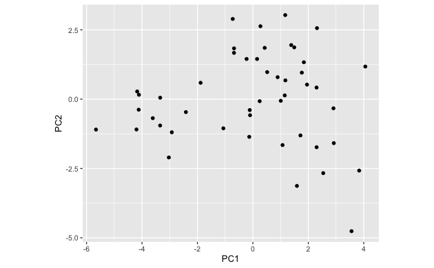

```r
####
ggplot(as.data.frame(predictors_PCA$x), aes(x = PC1, y = PC2)) +
  geom_point() + coord_fixed()
```

Lets plot our PC values (scree plot) to get an overall picture of variability among PC components. For more code examples on Scree plots check this [site](http://www.sthda.com/english/wiki/eigenvalues-quick-data-visualization-with-factoextra-r-software-and-data-mining)

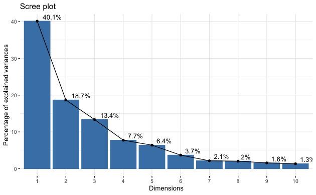

```r
fviz_eig(predictors_PCA, addlabels=TRUE, hjust = -0.3)
```

Cool we can see that the first 4-5 PC components have the most variance. I will be grabbing the first 5 PC’s for our linear model. The first 5 PC’s capture ~85% of the variance. (Office hours recommends 85-95% of the variance). We could additionally perform cross-validations to find the best n-value.

```r
#### Check our PCA object

str(predictors_PCA)
```

```
List of 5
 $ sdev    : num [1:15] 2.453 1.674 1.416 1.078 0.979 ...
 $ rotation: num [1:15, 1:15] -0.304 -0.331 0.34 0.309 0.311 ...
  ..- attr(*, "dimnames")=List of 2
  .. ..$ : chr [1:15] "M" "So" "Ed" "Po1" ...
  .. ..$ : chr [1:15] "PC1" "PC2" "PC3" "PC4" ...
 $ center  : Named num [1:15] 13.86 0.34 10.56 8.5 8.02 ...
  ..- attr(*, "names")= chr [1:15] "M" "So" "Ed" "Po1" ...
 $ scale   : Named num [1:15] 1.257 0.479 1.119 2.972 2.796 ...
  ..- attr(*, "names")= chr [1:15] "M" "So" "Ed" "Po1" ...
 $ x       : num [1:47, 1:15] -4.2 1.17 -4.17 3.83 1.84 ...
  ..- attr(*, "dimnames")=List of 2
  .. ..$ : NULL
  .. ..$ : chr [1:15] "PC1" "PC2" "PC3" "PC4" ...
 - attr(*, "class")= chr "prcomp"
```

our PC components are stored in $x, now lets grab the first 5

```r
results_PC <- as.data.frame(predictors_PCA$x[,1:5])
```

Ok now lets perform a linear regression model using the new PC’s and the responses (Crime column) I saved earlier as a response data frame

```r
### lm model with first 5 PC's
response <- as.numeric(response[[1]]) #make sure we chnage the Crime column from integer to numeric
```

```r
lm_model_PC <- lm(response ~., data = results_PC)
summary(lm_model_PC)
```

```
Call:
lm(formula = response ~ ., data = results_PC)

Residuals:
    Min      1Q  Median      3Q     Max
-420.79 -185.01   12.21  146.24  447.86

Coefficients:
            Estimate Std. Error t value Pr(>|t|)
(Intercept)   905.09      35.59  25.428  < 2e-16 ***
PC1            65.22      14.67   4.447 6.51e-05 ***
PC2           -70.08      21.49  -3.261  0.00224 **
PC3            25.19      25.41   0.992  0.32725
PC4            69.45      33.37   2.081  0.04374 *
PC5          -229.04      36.75  -6.232 2.02e-07 ***
---
Signif. codes:  0 ‘***’ 0.001 ‘**’ 0.01 ‘*’ 0.05 ‘.’ 0.1 ‘ ’ 1

Residual standard error: 244 on 41 degrees of freedom
Multiple R-squared:  0.6452,    Adjusted R-squared:  0.6019
F-statistic: 14.91 on 5 and 41 DF,  p-value: 2.446e-08
```

The homework question asks us to specify our new model in terms of the original variables *(not the principal components)*. To do this we need to convert the coefficients of the PC’s (from our new linear model) back to the coefficients from the original Crime data predictors.

```r
#### extracting the coefficients form our lm

lm_coeffs <- lm_model_PC$coefficients[2:6] #grabbed our coefficients ignoring the y-intercept as a data frame
lm_coeff_yintercept <- lm_model_PC$coefficients[1]
lm_coeffs #b values
```

```
       PC1        PC2        PC3        PC4        PC5
  65.21593  -70.08312   25.19408   69.44603 -229.04282
```

```r
lm_coeff_yintercept # y-intercept or b0
```

```
(Intercept)
   905.0851
```

```r
#### Grabbing some components from the first 5 PC's in the PCA object that we will need for our back-calculations

PCA_rotation <- predictors_PCA$rotation[,1:5] #eigenvectors for the first 5 PC's
PCA_scale <- predictors_PCA$scale #scaling factors
PCA_center <- predictors_PCA$center #means of original values
predictors_PCA_PC <- predictors_PCA$x[,1:5] #first 5 PC's


PCA_rotation
```

```
               PC1         PC2           PC3         PC4         PC5
M      -0.30371194  0.06280357  0.1724199946 -0.02035537 -0.35832737
So     -0.33088129 -0.15837219  0.0155433104  0.29247181 -0.12061130
Ed      0.33962148  0.21461152  0.0677396249  0.07974375 -0.02442839
Po1     0.30863412 -0.26981761  0.0506458161  0.33325059 -0.23527680
Po2     0.31099285 -0.26396300  0.0530651173  0.35192809 -0.20473383
LF      0.17617757  0.31943042  0.2715301768 -0.14326529 -0.39407588
M.F     0.11638221  0.39434428 -0.2031621598  0.01048029 -0.57877443
Pop     0.11307836 -0.46723456  0.0770210971 -0.03210513 -0.08317034
NW     -0.29358647 -0.22801119  0.0788156621  0.23925971 -0.36079387
U1      0.04050137  0.00807439 -0.6590290980 -0.18279096 -0.13136873
U2      0.01812228 -0.27971336 -0.5785006293 -0.06889312 -0.13499487
Wealth  0.37970331 -0.07718862  0.0100647664  0.11781752  0.01167683
Ineq   -0.36579778 -0.02752240 -0.0002944563 -0.08066612 -0.21672823
Prob   -0.25888661  0.15831708 -0.1176726436  0.49303389  0.16562829
Time   -0.02062867 -0.38014836  0.2235664632 -0.54059002 -0.14764767
```

```r
predictors_PCA_PC
```

```
             PC1         PC2         PC3         PC4          PC5
 [1,] -4.1992835 -1.09383120 -1.11907395  0.67178115  0.055283376
 [2,]  1.1726630  0.67701360 -0.05244634 -0.08350709 -1.173199821
 [3,] -4.1737248  0.27677501 -0.37107658  0.37793995  0.541345246
 [4,]  3.8349617 -2.57690596  0.22793998  0.38262331 -1.644746496
 [5,]  1.8392999  1.33098564  1.27882805  0.71814305  0.041590320
 [6,]  2.9072336 -0.33054213  0.53288181  1.22140635  1.374360960
 [7,]  0.2457752 -0.07362562 -0.90742064  1.13685873  0.718644387
 [8,] -0.1301330 -1.35985577  0.59753132  1.44045387 -0.222781388
 [9,] -3.6103169 -0.68621008  1.28372246  0.55171150 -0.324292990
[10,]  1.1672376  3.03207033  0.37984502 -0.28887026 -0.646056610
[11,]  2.5384879 -2.66771358  1.54424656 -0.87671210 -0.324083561
[12,]  1.0065920 -0.06044849  1.18861346 -1.31261964  0.358087724
[13,]  0.5161143  0.97485189  1.83351610 -1.59117618  0.599881946
[14,]  0.4265556  1.85044812  1.02893477 -0.07789173  0.741887592
```

[output cut: 33 more lines]

Grabbing the eigenvectors for the first 5 PC’s from our PCA model

```r
#### eigenvectors values from PCA model
PCA_rotation_transpose <- t(PCA_rotation)
PCA_rotation_transpose
```

```
              M          So          Ed         Po1         Po2         LF         M.F         Pop          NW          U1          U2      Wealth
PC1 -0.30371194 -0.33088129  0.33962148  0.30863412  0.31099285  0.1761776  0.11638221  0.11307836 -0.29358647  0.04050137  0.01812228  0.37970331
PC2  0.06280357 -0.15837219  0.21461152 -0.26981761 -0.26396300  0.3194304  0.39434428 -0.46723456 -0.22801119  0.00807439 -0.27971336 -0.07718862
PC3  0.17241999  0.01554331  0.06773962  0.05064582  0.05306512  0.2715302 -0.20316216  0.07702110  0.07881566 -0.65902910 -0.57850063  0.01006477
PC4 -0.02035537  0.29247181  0.07974375  0.33325059  0.35192809 -0.1432653  0.01048029 -0.03210513  0.23925971 -0.18279096 -0.06889312  0.11781752
PC5 -0.35832737 -0.12061130 -0.02442839 -0.23527680 -0.20473383 -0.3940759 -0.57877443 -0.08317034 -0.36079387 -0.13136873 -0.13499487  0.01167683
             Ineq       Prob        Time
PC1 -0.3657977826 -0.2588866 -0.02062867
PC2 -0.0275223960  0.1583171 -0.38014836
PC3 -0.0002944563 -0.1176726  0.22356646
PC4 -0.0806661240  0.4930339 -0.54059002
PC5 -0.2167282285  0.1656283 -0.14764767
```

```r
transformed_coefficients <- PCA_rotation_transpose*lm_coeffs
transformed_coefficients
```

```
             M          So         Ed       Po1       Po2         LF         M.F       Pop         NW          U1         U2     Wealth          Ineq
PC1 -19.806857 -21.5787314  22.148731 20.127861 20.281688  11.489584   7.5899743  7.374511 -19.146515   2.6413344   1.181861 24.7627042 -23.855842638
PC2  -4.401470  11.0992170 -15.040645 18.909660 18.499350 -22.386680 -27.6368772 32.745255  15.979735  -0.5658784  19.603185  5.4096192   1.928855344
PC3   4.343963   0.3915994   1.706637  1.275975  1.336927   6.840952  -5.1184833  1.940476   1.985688 -16.6036305 -14.574790  0.2535725  -0.007418555
PC4  -1.413599  20.3110062   5.537887 23.142930 24.440009  -9.949206   0.7278145 -2.229574  16.615637 -12.6941068  -4.784354  8.1819594  -5.601942128
PC5  82.072312  27.6251516   5.595146 53.888461 46.892813  90.260251 132.5641295 19.049569  82.637245  30.0890646  30.919606 -2.6744930  49.640045057
          Prob       Time
PC1 -16.883531  -1.345318
PC2 -11.095354  26.641983
PC3  -2.964654   5.632551
PC4  34.239247 -37.541831
PC5 -37.935972  33.817638
```

```r
#### reversing the scaling and centering prcomp() did using mean and sd


mu <- colMeans(CrimeData[ , 1:15]) #mean from each column except the response column from the original dataset
sd <- apply(CrimeData[,1:15], 2,sd) #standard deviation from each column except the response column from the original dataset

unscaled_transformed_coefficients <- transformed_coefficients / sd #reverses the scaling process


y_intercept <- as.numeric(lm_coeff_yintercept - sum((mu / sd) * transformed_coefficients)) # adjusting the centered y-intercept
y_intercept
```

```
[1] -3585.999
```

```r
unscaled_transformed_coefficients <- as.data.frame(unscaled_transformed_coefficients)
unscaled_transformed_coefficients
```

|  | M | So | Ed | Po1 | Po2 | LF | M.F | Pop | NW | U1 | U2 | Wealth | Ineq | Prob | Time |
| --- | --- | --- | --- | --- | --- | --- | --- | --- | --- | --- | --- | --- | --- | --- | --- |
| PC1 | -15.7602113 | -533.97086867 | 26.22563751 | 16.015633 | 501.8752254 | 13.60446692 | 6.0393025 | 182.48403053 | -22.67080495 | 2.101696 | 29.2454431 | 29.320763799 | -18.981968204 | -4.177870e+02 | -1.592950e+00 |
| PC2 | -9.1893489 | 3.76661330 | -0.01558762 | 39.479416 | 6.2779112 | -0.02320081 | -57.7000216 | 11.11237958 | 0.01656087 | -1.181436 | 6.6525067 | 0.005606349 | 4.027046692 | -3.765302e+00 | 2.761086e-02 |
| PC3 | 3.8830458 | 0.01028598 | 0.42777091 | 1.140587 | 0.0351165 | 1.71469372 | -4.5753857 | 0.05096966 | 0.49771529 | -14.841899 | -0.3828299 | 0.063558283 | -0.006631408 | -7.787132e-02 | 1.411806e+00 |
| PC4 | -0.4756555 | 1.97522508 | 243.56306826 | 7.787258 | 2.3767665 | -437.57830913 | 0.2448989 | -0.21682385 | 730.77614616 | -4.271381 | -0.4652736 | 359.852634976 | -1.884971603 | 3.329733e+00 | -1.651136e+03 |
| PC5 | 29.3520894 | 1532.28047446 | 0.78950603 | 19.272504 | 2600.9972006 | 12.73621920 | 47.4098276 | 1056.61984404 | 11.66057106 | 10.760961 | 1715.0135095 | -0.377385712 | 17.753113068 | -2.104189e+03 | 4.771855e+00 |

```r
NA
NA
```

Now lets grab the de-centered y-intercept and the un-scaled coefficients to get a prediction using the new city data from last week’s homework

```r
### new data frame with city info provided by previous homework question
city_data <- data.frame(M = 14.0,So = 0, Ed = 10.0, Po1 = 12.0, Po2 = 15.5,LF = 0.640, M.F = 94.0, Pop = 150, NW = 1.1, U1 = 0.120, U2 = 3.6, Wealth = 3200, Ineq = 20.1, Prob = 0.040,Time = 39.0)
city_data <- as.matrix(city_data)
city_data
```

```
      M So Ed Po1  Po2   LF M.F Pop  NW   U1  U2 Wealth Ineq Prob Time
[1,] 14  0 10  12 15.5 0.64  94 150 1.1 0.12 3.6   3200 20.1 0.04   39
```

```r
predicted_city <- sum(city_data * unscaled_transformed_coefficients) + y_intercept
predicted_city
```

```
[1] 2108.92
```

Our predicted value is 2108.92. My previous predicted value from Homework 3 was 1304.

#### Question 10.1

Using the same crime data set uscrime.txt as in Questions 8.2 and 9.1, find the best model you can using (a) a regression tree model, and (b) a random forest model. InR,youcanusethetreepackageortherpartpackage,andtherandomForestpackage. For each model, describe one or two qualitative takeaways you get from analyzing the results (i.e., don’t just stop when you have a good model, but interpret it too).

### 10.1.a

```r
tree_model <- tree(Crime ~., data = CrimeData)
summary(tree_model)
```

```
Regression tree:
tree(formula = Crime ~ ., data = CrimeData)
Variables actually used in tree construction:
[1] "Po1" "Pop" "LF"  "NW"
Number of terminal nodes:  7
Residual mean deviance:  47390 = 1896000 / 40
Distribution of residuals:
    Min.  1st Qu.   Median     Mean  3rd Qu.     Max.
-573.900  -98.300   -1.545    0.000  110.600  490.100
```

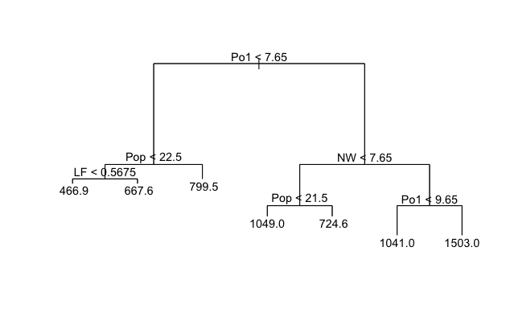

```r
plot(tree_model)
text(tree_model)
```

```r
tree_model$frame
```

|  | var | n | dev | yval | splits |
| --- | --- | --- | --- | --- | --- |
| 1 | Po1 | 47 | 6880927.66 | 905.0851 |  |
| 2 | Pop | 23 | 779243.48 | 669.6087 |  |
| 4 | LF | 12 | 243811.00 | 550.5000 |  |
| 8 |  | 7 | 48518.86 | 466.8571 |  |
| 9 |  | 5 | 77757.20 | 667.6000 |  |
| 5 |  | 11 | 179470.73 | 799.5455 |  |
| 3 | NW | 24 | 3604162.50 | 1130.7500 |  |
| 6 | Pop | 10 | 557574.90 | 886.9000 |  |
| 12 |  | 5 | 146390.80 | 1049.2000 |  |
| 13 |  | 5 | 147771.20 | 724.6000 |  |

[output cut: 3 more lines]

```r
tree_model$where
```

```
 1  2  3  4  5  6  7  8  9 10 11 12 13 14 15 16 17 18 19 20 21 22 23 24 25 26 27 28 29 30 31 32 33 34 35 36 37 38 39 40 41 42 43 44 45 46 47
 6 13  4 13  9 10 12 13  6  5 13  6  6  5  6 12  4 13 10 13  6  4 12  9  5 13  4 12 13  6  4 12  6  9 10  9  6  5  6 12  5  4  6 10  4 10  9
```

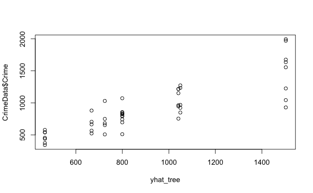

```r
yhat_tree <- predict(tree_model)
plot(yhat_tree, CrimeData$Crime)
```

```r
prune.tree(tree_model)$size
```

```
[1] 7 6 5 4 3 2 1
```

```r
prune.tree(tree_model)$dev
```

```
[1] 1895722 2013257 2276670 2632631 3364043 4383406 6880928
```

```r
set.seed(100)
cv.tree(tree_model)$dev
```

```
[1] 7450483 7360619 7251929 7468107 7517293 6215352 7336773
```

pruning tree branches

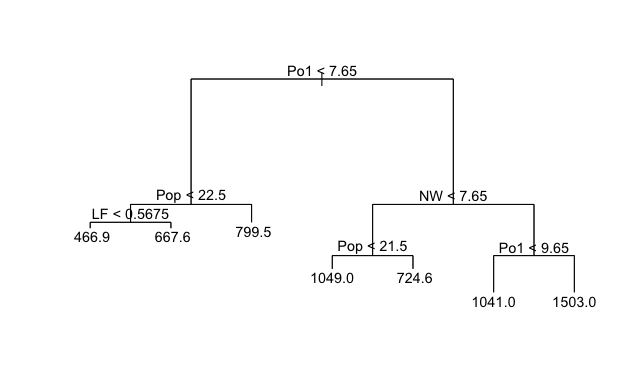

```r
tree_prune <- prune.tree(tree_model, best = 7)
plot(tree_prune)
text(tree_prune)
```

### 10.1.b

```r
#### random forest model of Crime dataset
randomForest_combined <- data.frame(response, predictors) # response and predictors are variables from the Crime dataset I made for question 9.1

set.seed(100)
randomForest_model <- randomForest(response~., data = randomForest_combined, importance = TRUE)
summary(randomForest_model)
```

```
                Length Class  Mode
call              4    -none- call
type              1    -none- character
predicted        47    -none- numeric
mse             500    -none- numeric
rsq             500    -none- numeric
oob.times        47    -none- numeric
importance       30    -none- numeric
importanceSD     15    -none- numeric
localImportance   0    -none- NULL
proximity         0    -none- NULL
ntree             1    -none- numeric
mtry              1    -none- numeric
forest           11    -none- list
coefs             0    -none- NULL
y                47    -none- numeric
test              0    -none- NULL
inbag             0    -none- NULL
terms             3    terms  call
```

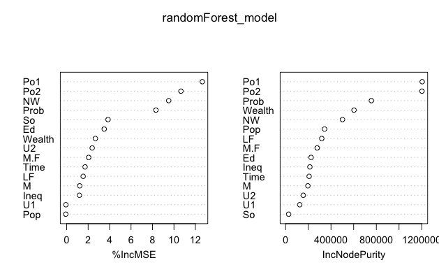

```r
varImpPlot(randomForest_model)
```

#### Question 10.2

Describe a situation or problem from your job, everyday life, current events, etc., for which a logistic regression model would be appropriate. List some (up to 5) predictors that you might use.

#### Answer

A situation in my job (laboratory) that benefits from a logistic regression model is predicting if a compound will be effective in binding to a target protein.

This is a binary outcome (yes/no)

Some useful predictors: 1. Concentration of the compound 2. Affinity of binding 3. % of cells that are viable (this could indicate toxicity effects from the compound)

a logistic regression model could help determine the probability that the compound is effective.